# Exercise 8 - Quantitative Genetics

Mahdi Robbani

March 8, 2020

# Quantitative genetics

**Hans R Siegismund**

The focus of these exercises is to

- partition the phenotypic variance of a quantitative trait
- estimate the heritability for two human traits, height and number of children
- study the effect of prolonged selection on the heritability of a trait.

**Exercise 1** In this exercise, we will analyse quantitative genetic variation in humans. The data has been collected in a course on evolutionary biology at the University of Copenhagen.

Please note, that the number of children for the different generations is biased. We do of course not include the individuals in the parent or grandparent generation that did not get a child.

Move to the exercises directory and create the QuantitativeGenetics folder and get the data (human.txt).

```bash
cd ~/exercises
mkdir QuantitativeGenetics
cd QuantitativeGenetics
cp ~/groupdirs/SCIENCE-BIO-Popgen_Course/exercises/QuantitativeGenetics/human.txt .
```

Once the data have been copied wo the QuantitativeGenetics folder, one can view them on the screen with the head command

```bash
head human.txt
```

It looks like this

| Sex | Height | HeightF | HeightM | ChildFF | ChildF | ChildMM | ChildM |
| --- | --- | --- | --- | --- | --- | --- | --- |
| female | 172 | 178 | 167 | 3 | 2 | 2 | 2 |
| female | 165 | 170 | 168 | 2 | 1 | 2 | 1 |
| female | 173 | 167 | 171 | 4 | 2 | 4 | 2 |
| female | 168 | 197 | 168 | 2 | 2 | 3 | 2 |
| female | 166 | 175 | 160 | 4 | 4 | 5 | 4 |
| female | 162 | 189 | 158 | 2 | 2 | 2 | 2 |
| female | 180 | 182 | 160 | 5 | 2 | 2 | 2 |
| female | 180 | 186 | 178 | 3 | 3 | 2 | 2 |
| female | 176 | 196 | 166 | 2 | 1 | 2 | 1 |

which is (almost) self-explanatory

| Height is in cm |
| --- |
| F Father |
| M Mother |
| FF Father’s father |
| MM Mother’s mother |

We want to estimate the “narrow sense” heritability, *h*<sup>2</sup>, for the traits height and number of offspring. The “narrow sense” heritability is defined as the fraction of the additive genetic variance, *V<sub>A</sub>*, of the total phenotypic variance, *V<sub>P</sub>*,

*h*<sup>2</sup> = *V<sub>A</sub>*/*V<sub>P</sub>*

However, not always do we have a direct way to calculate *V<sub>A</sub>*. Luckily, in some experimental designs, the heritability can be estimated from regression among relatives. It can be shown that the heritability equals the regression coefficient *b* between the offspring and the *average midparent* value for a trait

*h*<sup>2</sup><sub>*N*</sub> = *b*

If the regression is carried out between offspring and a *single parent,* it can be shown that the heritability is equal to twice the regression coefficient between the offspring and the parent,

*h*<sup>2</sup><sub>*N*</sub> = 2*b*.

The regression coefficient *b* is found as

*b* = *Cov*( *x*, *y*)/*V* (*x*)

*Cov*(*x*, *y*) is the covariance among *x* and *y.* However, programing languages like R calculate the regression coefficient directly from the data, provided that one has specified a model.

1. Read the data into R, take a look at the distribution for the two sexes in the two generations, and get a summary of the data

#### >R

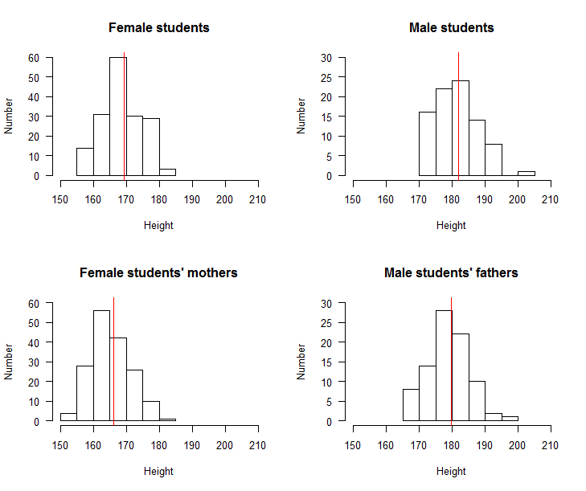

```r
###Set the path to the folder with your data.
setwd("~/exercises/QuantitativeGenetics")
human <- read.table(file="human.txt",header = TRUE, dec="t")
###How does the data look like?
head (human)
###First, we partition the data set into male and female data sets
females <- human[human$Sex=="female",]
males <- human[human$Sex=="male",]
par(mfrow=c(2,2))     ###Graphics window with 2 x 2 figures
hist(females$Height,xlim=c(150,210),ylim=c(0,60),breaks=6,las=1,
    ylab="Number",xlab="Height",main="Female students")
abline(v=mean(females$Height), col="red")
hist(males$Height,xlim=c(150,210),ylim=c(0,30),breaks=6,las=1,
     ylab="Number",xlab="Height",main="Male students")
abline(v=mean(males$Height), col="red")
hist(females$HeightM,xlim=c(150,210),ylim=c(0,60),breaks=6,las=1,
     ylab="Number",xlab="Height",main="Female students' mothers")
abline(v=mean(females$HeightM), col="red")
hist(males$HeightF,xlim=c(150,210),ylim=c(0,30),breaks=6,las=1,
     ylab="Number",xlab="Height",main="Male students' fathers")
abline(v=mean(males$HeightF), col="red")
summary(human)
```

2. Take a look at the mean of female students and their mothers. And look at the “Mean” for the Height variable and the HeightM variable. How does the mean change over the generations?

#### >R

```r
summary(females)
```

**Answer:**

| Mean Height | 169.4 cm |
| --- | --- |
| Mean HeightM | 166.1cm |

Conclusion daughters are *on average* taller than their mothers by 3.3 cm.

3. Do the same for male students.

#### >R

```r
summary(males)
```

**Answer:**

| Mean Height | 181.8 cm |
| --- | --- |
| Mean HeightM | 179.6 cm |

Conclusion: sons daughters are *on average* taller than their fathers by 2.2 cm.

4. Is there any sign of assortative mating with regard to height? (That is, do people prefer a partner like themselves?)

To answer this, we can see if there is a relationship between the height of the father and the height of the mother. First, we plot all the points. Then we create a model and summarize it.

#### >R

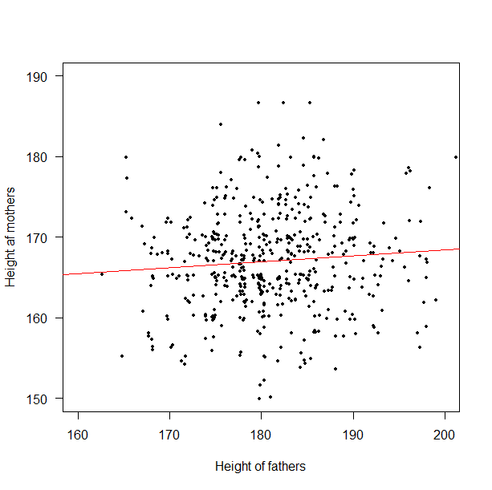

```r
par(mfrow=c(1,1))   ###Graphics window with 1 figure
plot(jitter(human$HeightF,factor=2),jitter(human$HeightM,factor=2),
     pch=20,cex=0.8,
     xlim=c(160,200),ylim=c(150,190),
     xlab="Height of fathers", ylab= "Height af mothers",las=1)
model <- lm(human$HeightM~human$HeightF)
abline(model, col="red")   ###Regression line
summary(model)
```

```bash
Call:
lm(formula = human$HeightM ~ human$HeightF)

Residuals:
   Min      1Q  Median      3Q     Max
-16.331  -4.156  -0.496   3.862  14.743

Coefficients:
              Estimate Std. Error t value Pr(>|t|)
(Intercept)   159.68027   10.26615  15.554   <2e-16 ***
human$HeightF   0.03674    0.05690   0.646    0.519
---
Signif. codes:
0 ‘***’ 0.001 ‘**’ 0.01 ‘*’ 0.05 ‘.’ 0.1 ‘ ’ 1

Residual standard error: 5.97 on 250 degrees of freedom
Multiple R-squared:  0.001665,  Adjusted R-squared:  -0.002328
F-statistic: 0.417 on 1 and 250 DF,  p-value: 0.519
```

The scatter plot of mother’s height against father’s height does not reveal any strong relationship for these two variables. Also, the regression coefficient is not statistically different from zero with *P*-value = 0.519 (i.e. it is essentially zero or in other words completely horizontal).

Conclusion: there is no assortative mating with regard to parental height.

5. Take a look at the distribution of number of offspring for the two different generations for each sex separately. We do this by creating the histograms

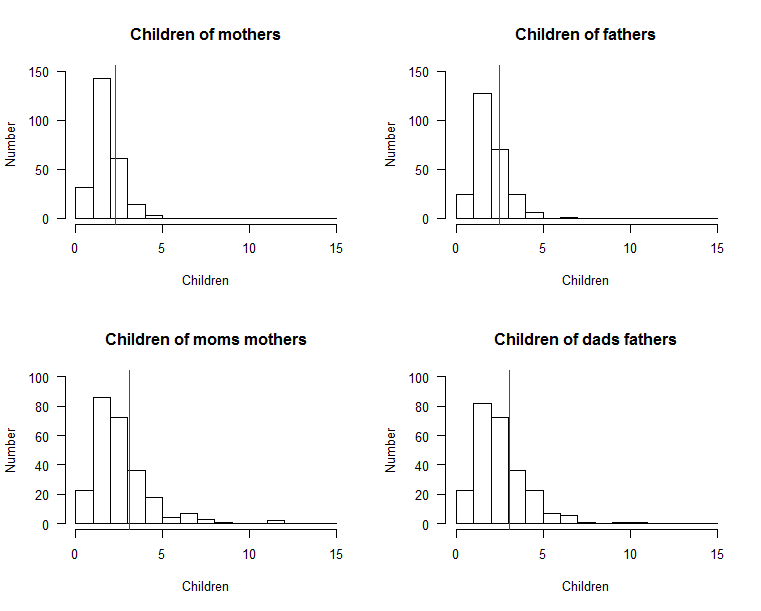

```r
brk<- seq(0, 15,1)   ###Set inervals for the histograms
par(mfrow=c(2,2))    ###Graphics window with 2 x 2 figures
maxChild <- 15
CM<- hist(human$ChildM,xlim=c(0,maxChild),ylim=c(0,150),las=1,
          breaks=brk,ylab="Number",xlab="Children",main="Children of mothers")
abline(v=mean(human$ChildM), col="red")
CF<- hist(human$ChildF,xlim=c(0,maxChild),ylim=c(0,150),las=1,
          breaks=brk,ylab="Number",xlab="Children",main="Children of fathers")
abline(v=mean(human$ChildF), col="red")
CMM<- hist(human$ChildMM,xlim=c(0,maxChild),ylim=c(0,100),las=1,
           breaks=brk,ylab="Number",xlab="Children",main="Children of moms mothers")
abline(v=mean(human$ChildMM), col="red")
CFF<- hist(human$ChildFF,xlim=c(0,maxChild),ylim=c(0,100),las=1,
           breaks=brk,ylab="Number",xlab="Children",main="Children of dads fathers")
abline(v=mean(human$ChildFF), col="red")
```

6. How does the maximum number of children change over the generations? Use the summary function again and look for the Max. row

```r
summary(human)
```

For female students, the maximum number of children dropped from 12 (grandmother level) to 5 (mother level). For male students, the maximum number of children dropped from 11 (grandfather level) to 7 (father level).

7. How do the mean and variance change among generations?

The mean can be found in the data summary. The variance can be calculated using these commands

```r
var(human$ChildM)
var(human$ChildMM)
var(human$ChildF)
var(human$ChildFF)
```

Putting the data together in a table

|  | Mean | Variance |
| --- | --- | --- |
| Number of children of mother | 2.266 | 0.6262411 |
| Number of children of father | 2.464 | 0.8552931 |
| Number of children of maternal grandmother | 3.075 | 2.811026 |
| Number of children of paternal grandfather | 3.075 | 2.380747 |

We observe that even though the mean has reduced slightly, the variance has undergone a more dramatic drop. This means that people in younger generations tend to have fewer children and somewhat a similar number of children.

8. Take a look at the variance in the different generations. From the change of the variances would you predict that genetic drift has increased or decreased over the generations?

It can be shown that for the Wright-Fisher model the variance (σ<sup>2</sup>) in number of gametes passed on to the next generation is equal to 2. In that case, the census population size is equal to the effective population size. Effective population size is inversely related to genetic drift (i.e. smaller populations undergo more drift and vice versa).

The effective population size differs from the census size as illustrated in this figure

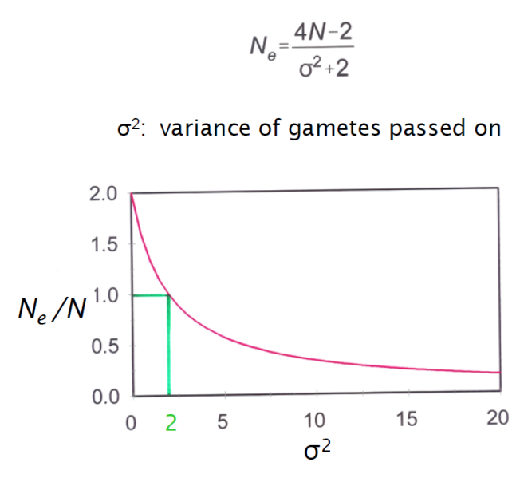

We can see that the smaller the variance in gametes passed on, the larger the effective population size is relative to the census size. The variance in number of offspring was substantially smaller for the students’ parental generation than for the grandparental generation. Therefore, genetic drift has decreased.

9. Estimate the “narrow sense” heritability for height in humans (for both sexes separately). Start by making plots for males and females.

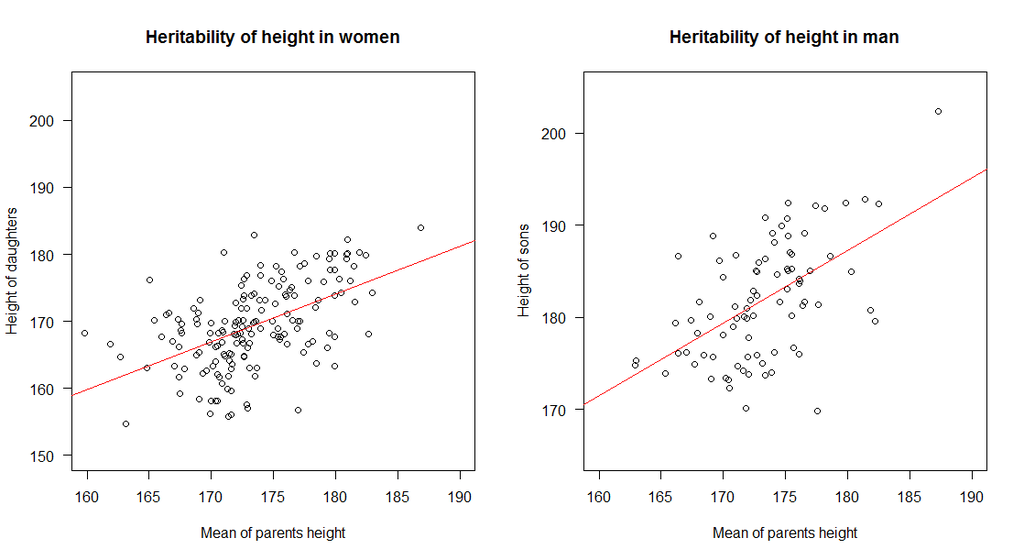

```r
par(mfrow=c(1,2))
###Females:
females$AveHeightParents<-(females$HeightF+females$HeightM)/2
plot(jitter(females$AveHeightParents,factor=2),jitter(females$Height,factor=2),xlim=c(160,190),
      ylim=c(150,205),xlab="Mean of parents height", ylab= "Height of daughters",las=1,
      main="Heritability of height in women")
abline(lm(females$Height~females$AveHeightParent), col="red")
summary(lm(females$Height~females$AveHeightParents)) #to see the significance of the coefficients
#####Males:
males$AveHeightParents<-(males$HeightF+males$HeightM)/2
plot(jitter(males$AveHeightParents,factor=2),jitter(males$Height,factor=2),xlim=c(160,190),
      ylim=c(165,205),xlab="Mean of parents height", ylab= "Height of sons",las=1,
      main="Heritability of height in man")
abline(lm(males$Height~males$AveHeightParents), col="red")
summary(lm(males$Height~males$AveHeightParents)) #to see the significance of the coefficients
```

We can summarize the two regression models for males and females, and look for the regression coefficient in the results. Remember that the regression coefficients are actually the estimates of the heribality of height

```r
###Females:
summary(lm(females$Height~females$AveHeightParents)) #to see the significance of the coefficients
#####Males:
summary(lm(males$Height~males$AveHeightParents)) #to see the significance of the coefficients
```

**Females**

```bash
Call:
lm(formula = females$Height ~ females$AveHeightParents)

Residuals:
     Min       1Q   Median       3Q      Max
-14.9335  -3.2055   0.0014   4.1464  13.5518

Coefficients:
                         Estimate Std. Error t value Pr(>|t|)
(Intercept)              46.24875   15.54170   2.976  0.00336
females$AveHeightParents  0.71008    0.08961   7.925 3.24e-13

(Intercept)              **
females$AveHeightParents ***
---
Signif. codes:  0 ‘***’ 0.001 ‘**’ 0.01 ‘*’ 0.05 ‘.’ 0.1 ‘ ’ 1

Residual standard error: 5.354 on 165 degrees of freedom
Multiple R-squared:  0.2757,  Adjusted R-squared:  0.2713
F-statistic:  62.8 on 1 and 165 DF,  p-value: 3.239e-13
```

**Males**

```bash
Call:
lm(formula = males$Height ~ males$AveHeightParents)

Residuals:
     Min       1Q   Median       3Q      Max
-15.2278  -3.4388   0.1119   3.7174  10.4790

Coefficients:
                       Estimate Std. Error t value Pr(>|t|)
(Intercept)             45.1732    22.9216   1.971   0.0521 .
males$AveHeightParents   0.7890     0.1323   5.963 5.82e-08 ***
---
Signif. codes:  0 ‘***’ 0.001 ‘**’ 0.01 ‘*’ 0.05 ‘.’ 0.1 ‘ ’ 1

Residual standard error: 5.316 on 83 degrees of freedom
Multiple R-squared:  0.2999,  Adjusted R-squared:  0.2915
F-statistic: 35.56 on 1 and 83 DF,  p-value: 5.822e-08
```

So, for females (0.71008), height is a bit less heritable than for males (0.7890).